# Expanding on the Bak-Sneppen model

By Hildebert Moulié, Philippe Nicolau, Louis Weyland & Binjie Zhou

[figure not shown]

# Presentation overview

1. Introduction
2. The Bak-Sneppen Model
3. Properties
4. Model behavior
5. Metrics results
   - Avalanche time
   - Mutation Distance
   - Impact of percentage of empty nodes
   - Cluster size distribution for different grid sizes
   - Cluster size comparison between 2D and 3D
   - Fitness distribution at steady state
6. Conclusion
7. Further Research
8. References

# Introduction

After having looked into the Bak-Sneppen model, which is originally used on a one dimensional ring, we believed it to be very limited in its use. In order for it to be a better representation of reality, two dimensional and three dimensional versions of the model were coded using Python 3.8 with the *Networkx* package.

# The Bak-Sneppen Model

This simple and elegant model applied to the evolution of species exhibits self-organized criticality.

The model tries to represent the evolutionary dynamics of cohabiting species. It exhibits self organising behaviour, which can vary based on different parameters. Usually it is used in the context of a one dimensional lattice, but can be expanded to more dimensions. The Bak-Sneppen Model can also be purposed to research other areas, e.g. socio-economic segregation.

The original model was used on a 1D ring, where each site k on the ring has a quantity X_k, called fitness.

[figure not shown]

The fitness X of node k randomly changes if it is within a distance a of the node with the lowest fitness. If it is further away its fitness remains unchanged.

The new fitness values are independent and identically distributed random variables with uniform distribution (0,1). The distance a is simply the number of neighbours on each side that are taken into account.

# Properties

Initially, every node in the lattice has a uniformly distributed random fitness assigned to it.

The threshold is defined as the maximum fitness achieved by the node with the lowest fitness in the lattice.

An avalanche is defined as the time during which the threshold does not increase.

We define age as the number of iterations a node has gone through without mutating.

We have expanded the model to a 2D and 3D lattices.

# Model behavior

[figure not shown]

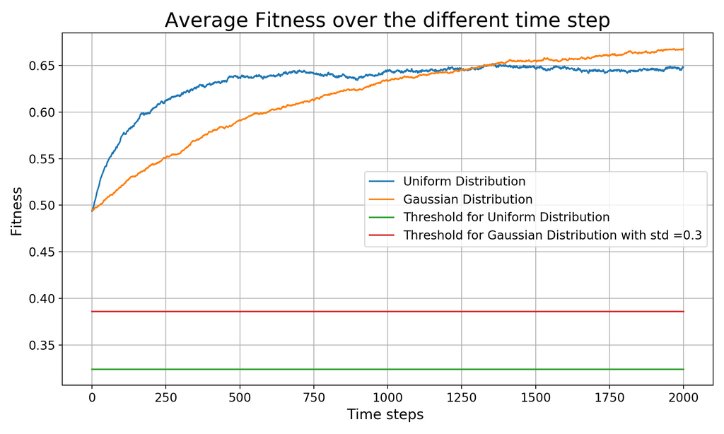

```python
comp_average_fitness(size=(20,20), iteration=2000, repetition=10, std=0.3)
```

[figure not shown]

# Metrics Results

## Avalanche time

- Avalanche distribution for uniform and guassian distribution

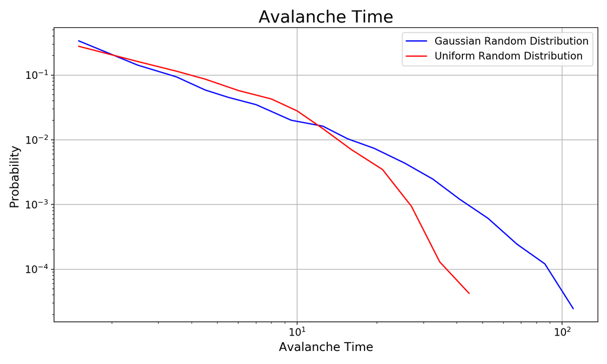

```
The slope of uniform disrtibution is 5.7954
uniform follows a lognormal distribution with a p = 0.8427
The slope of gaussian disrtibution is 3.1209
gaussian follows a lognormal distribution with a p = 0.0211
```

```python
comp_avalanche_time(size=(20,20), iteration=2000, repetition=10, std=0.2)
```

## Mutation distance

- Distance distribution between uniform and gaussian distribution

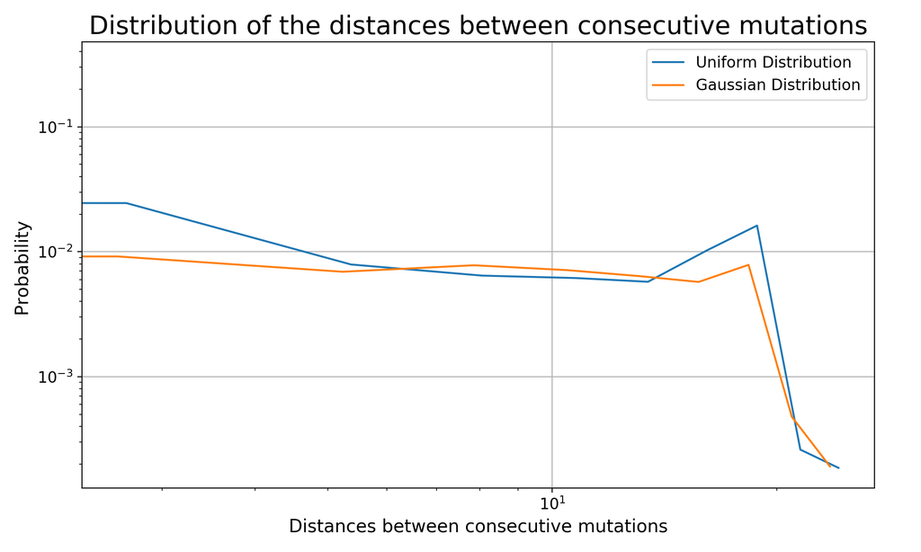

```
The slope of uniform disrtibution is 8.4514
uniform follows a lognormal distribution with a p = 0.0251
The slope of gaussian disrtibution is 11.0272
gaussian follows a lognormal distribution with a p = 0.0395
```

```python
comp_mutation_dist(size=(20,20), iteration=2000, repetition=10, std=0.2)
```

## Impact of percentage of empty node

- Impact of empty nodes on the avalanche time and thresholds

```python
is_free_variation(i_min=0, i_max=1, i_iter=6, iterations=20)
```

[figure not shown]

## Cluster size distribution for different grid sizes

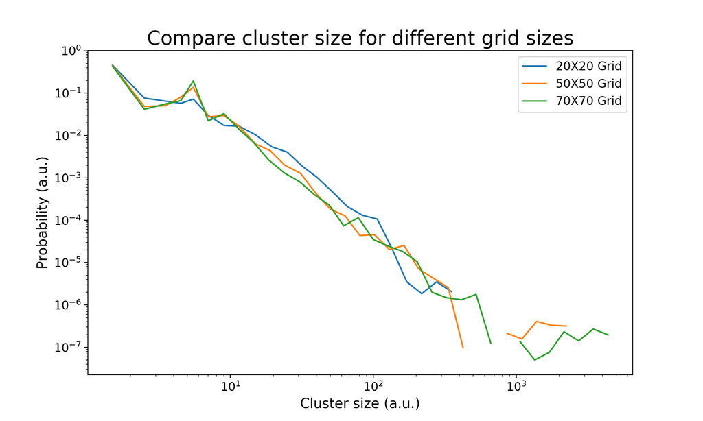

```
The slope of the20X20 grid's disrtibution is 2.9876
the20X20 grid's follows a powerlaw distribution with a p = 0.0
The slope of the 50X50 grid's disrtibution is 2.8099
the 50X50 grid's follows a powerlaw distribution with a p = 0.0
The slope of the 70X70 grid's disrtibution is 2.248
the 70X70 grid's follows a powerlaw distribution with a p = 0.0
```

```python
comp_cluster_sizes(iterations=2000)
```